# Coursera Machine Learning Project

Olusegun

8/10/2021

# Background

Using devices such as Jawbone Up, Nike FuelBand, and Fitbit it is now possible to collect a large amount of data about personal activity relatively inexpensively. These type of devices are part of the quantified self movement – a group of enthusiasts who take measurements about themselves regularly to improve their health, to find patterns in their behavior, or because they are tech geeks. One thing that people regularly do is quantify how much of a particular activity they do, but they rarely quantify how well they do it. In this project, your goal will be to use data from accelerometers on the belt, forearm, arm, and dumbell of 6 participants. They were asked to perform barbell lifts correctly and incorrectly in 5 different ways. More information is available from the website here: http://web.archive.org/web/20161224072740/http:/groupware.les.inf.puc-rio.br/har (see the section on the Weight Lifting Exercise Dataset).

## Goal

One thing that people regularly do is quantify how much of a particular activity they do, but they rarely quantify how well they do it. In this project, the goal will be to use data from accelerometers on the belt, forearm, arm, and dumbell of 6 participants to predict the manner in which they did the exercise. This is the “classe” variable in the training set.

# Analysis

Our outcome variable is classe, a factor variable. For this data set, “participants were asked to perform one set of 10 repetitions of the Unilateral Dumbbell Biceps Curl in 5 different fashions: - exactly according to the specification (Class A) - throwing the elbows to the front (Class B) - lifting the dumbbell only halfway (Class C) - lowering the dumbbell only halfway (Class D) - throwing the hips to the front (Class E)

Two models will be tested using decision tree and random forest. The model with higher accuracy will be chosen as our final model.

### Loading Libraries

```r
library(caret)
library(rattle)
library(randomForest)
```

### Read Data

```r
training <- read.csv("https://d396qusza40orc.cloudfront.net/predmachlearn/pml-training.csv",
                  header = T, na.strings=c(""," ","NA","#DIV/0!"))
validation <- read.csv("https://d396qusza40orc.cloudfront.net/predmachlearn/pml-testing.csv",
                header = T, na.strings=c(""," ","NA","#DIV/0!"))
dim(training); dim(validation)
```

```
## [1] 19622   160
```

```
## [1]  20 160
```

```r
training <- training[, which(colMeans(!is.na(training)) > 0.95)]
```

### Delete irrelevant variables

```r
training <- training[,-c(1:7)]
```

### Partition the data

```r
set.seed(3055)
train_pat <- createDataPartition(y=training$classe, p=0.75, list=FALSE)
trainset <- training[train_pat, ]
testset <- training[-train_pat, ]
```

### Model 1 - Decison Tree Model - Training and Testing

```r
set.seed(3055)
model1 <- train(classe ~ ., data=trainset, method="rpart", preProcess="pca")
print(model1$finalModel)
```

```
## n= 14718
##
## node), split, n, loss, yval, (yprob)
##       * denotes terminal node
##
## 1) root 14718 10533 A (0.28 0.19 0.17 0.16 0.18)
##   2) PC14< 0.8744393 13290  9140 A (0.31 0.19 0.19 0.17 0.14)
##     4) PC8>=-1.308686 10916  7073 A (0.35 0.18 0.22 0.11 0.14) *
##     5) PC8< -1.308686 2374  1398 D (0.13 0.24 0.062 0.41 0.16) *
##   3) PC14>=0.8744393 1428   596 E (0.025 0.24 0.022 0.13 0.58) *
```

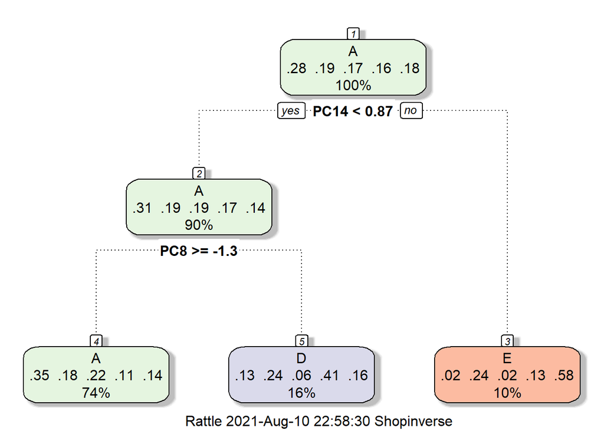

```r
fancyRpartPlot(model1$finalModel)
```

```r
pred1 <- predict(model1,newdata = testset)
```

### Model 2 - Random Forest Model - Training and Testing

```r
set.seed(3055)
model2 <- randomForest(factor(classe) ~ ., data=trainset, method="class")
print(model2$finalModel)
```

[output not shown]

```r
pred2 <- predict(model2,newdata = testset)
```

### Compare the accuracy of the two

Comparing model1 accuracy and model2 accuracy

```r
#Model 1
confusionMatrix(pred1, factor(testset$classe))$overall[1]
```

```
##  Accuracy
## 0.3851958
```

```r
#Model 2
confusionMatrix(pred2, factor(testset$classe))$overall[1]
```

```
##  Accuracy
## 0.9946982
```

### Predict classes of 20 test data

```r
col <- names(trainset)[1:52]
validation <- validation[,col]
pred <- predict(model2,newdata = validation)
print(pred)
```

```
##  1  2  3  4  5  6  7  8  9 10 11 12 13 14 15 16 17 18 19 20
##  B  A  B  A  A  E  D  B  A  A  B  C  B  A  E  E  A  B  B  B
## Levels: A B C D E
```